# POLI 572B

Michael Weaver

April 7, 2023

## Plan for Today

### Interaction Effects

### Robustness

1. Discussion of Papers
2. Review
   - McGrath
   - Truex
   - Kocher and Monteiro
   - Fowler and Hall

# Robustness

# McGrath

# Truex

# Kocher and Monteiro

# Fowler and Hall

# Interaction Effects

### Interaction Effects

Is the effect of some cause different for different sets of cases?

- heterogeneous treatment effects
- “moderators”: factors that intensify/weaken some causal effect
- differences-in-differences

### Interaction: **Example**

Did the local success of an explicitly secular political party, Indian National Congress (INC), reduce the likelihood of religious riots between Hindus and Muslims in India?

### Example

[Nellis et al](https://www.nowpublishers.com/article/Details/QJPS-15051) compare the incidence of riots in districts in which the INC barely won and barely lost MLA elections (w/ in 1 ppt).

They estimate the model:

$$\mathrm{Any \ Riot}_{it} = \alpha +
\beta_1 \mathrm{INC \ Victory}_{it} + \epsilon_{it}$$

|  | Any Riot |
| --- | --- |
| Intercept | 0.236 |
|  | (0.022) |
| INC Win | −0.076 |
|  | (0.031) |
| Num.Obs. | 644 |
| R2 | 0.009 |

### Example

Wilkinson (2004) argues that political parties work to stop religious riots in India when Muslims are electorally pivotal.

- Muslims are typically victims in riots; will vote against parties to punish them
- Muslims more pivotal when the effective number of parties is higher

### Example

If the INC was responsive to this electoral logic, we should expect causal effect of INC victory on riots to be stronger when the ENP was above the median:

This is a **Binary by Binary** interaction:

- INC win/lose is **binary**
- High/Low ENP is **binary**

### Interaction Effects

**How do we estimate an interaction effect?**

Include both causal variable and interacting variable, **AND** their product.

$y_i = \beta_0 + \beta_1 D_i + \beta_2 X_i+ \beta_3 D_iX_i + \epsilon_i$

### Interaction Effects | Example

Easy to do in `R`:

```r
m2 = lm(any_riot ~ INC_win*high_enp, data = riots)
m3 = lm(any_riot ~ INC_win + high_enp + INC_win:high_enp,
        data = riots)
```

`*` expands out the ‘main’ effects and interaction effects

`:` just multiplies two variables together, no ‘main’ effects

### Interaction Effects | Interpretation?

|  | Any Riot |
| --- | --- |
| Intercept | 0.242 |
|  | (0.032) |
| INC Win | −0.084 |
|  | (0.045) |
| high_enpTRUE | −0.009 |
|  | (0.045) |
| INC_win:high_enpTRUE | 0.012 |
|  | (0.063) |
| Num.Obs. | 636 |
| R2 | 0.010 |

### Interaction Effects | Example

Different intercepts (means) for each group:

|  | INC Lose | INC Win |
| --- | --- | --- |
| ENP Low | `Intercept` | `Intercept + INC_win` |
| ENP High | `Intercept + high_enp` | `Intercept + high_enp +` `INC_win + INC_win:high_enp` |

### Interaction Effects | Example

Interpretation:

Interaction Effects: Effect of INC victory differs across ENP?

- `INC_win:high_enp` tells us how much more likely riots are (on average) when INC wins vs loses in High ENP districts, compared to when INC wins vs loses in Low ENP districts.

“Main Effects”:

- `INC_win`: change probability of riot when INC wins (vs loses) in low ENP areas.
- `hign_enp`: difference in probability of riot in high vs low ENP areas where INC loses.

### Interaction Effects | DiD

Different intercepts (means) for each group:

|  | Untreated | Treated |
| --- | --- | --- |
| Pre | `Intercept` | `Intercept + Treated` |
| Post | `Intercept + Post` | `Intercept + Treated +` `Post + Treated:Post` |

`lm(Y ~ Treated*Post, data = data)`

### Interaction Effects | DiD

If we have many treated, many untreated units $i$, across multiple time periods $t$, it is common to do this:

```r
lm(Y ~ Treated*Post + dummy_i + dummy_t, data = data)
feols(Y ~ Treated*Post | dummy_i + dummy_t, data = data)
```

Which of these four coefficients will we be able to actually estimate? (think about linear independence)

`Intercept + Treated + Post + Treated:Post`

### Interaction Effects

#### **Continuous by Binary variable**

Rather than fitting different intercepts for groups:

- Slope of $x_1$ depends on binary indicator ($x_2$)
- effect of binary treatment ($x_2$) depends on level of continuous variable
- $\hat{\beta_1}$ for $x_1$ will be slope of $x_1$ when $x_2 = 0$
- $\hat{\beta_2}$ for $x_2$ will be mean of $x_2 = 1$ when $x_1 = 0$

**Assumptions**

- We assume the change is linear
- Both levels of binary variable present across all levels of continuous variable (common support)

## Interaction Effects

#### **Continuous by Continuous variable**

- Slope of $x_1$ depends on value of $x_2$
- Slope of $x_2$ depends on value of $x_1$
- $\hat{\beta_1}$ for $x_1$ will be slope of $x_1$ when $x_2 = 0$
- $\hat{\beta_2}$ for $x_2$ will be slope of $x_2$ when $x_1 = 0$

**Assumptions**

- We assume the change is linear
- all levels of one variable present across all levels of other variable (common support)
- This is much harder to achieve!

### Interaction Effects

We can look at voting for Black Suffrage in Iowa.

Recall: investigation of effect of enlistment rates in the Civil War and on change in voting for suffrage between 1857 and 1868 (pre- and post- war).

Does the effect of having veterans in a county depend on what happened during their military service?

- Does combat experience matter?

### Example:

|  | Suffrage Change |
| --- | --- |
| Intercept | 0.638 |
|  | (0.170) |
| Enlist Rate | −0.577 |
|  | (0.519) |
| Combat Days | −0.010 |
|  | (0.005) |
| Enlist X Combat | 0.031 |
|  | (0.016) |
| Num.Obs. | 79 |
| R2 | 0.193 |

### Example:

We can center both variables at $0$ to make it easier to interpret:

```r
iowa$enlist_pct_c = iowa$enlist_pct %>% scale(scale = F)
iowa$mean_combat_days_c = iowa$mean_combat_days %>% scale(scale = F)
lm_iowa_c = lm(Suffrage_Diff ~ enlist_pct_c*mean_combat_days_c, iowa)
```

|  | Suffrage Change |
| --- | --- |
| Intercept | 0.449 |
|  | (0.010) |
| Enlist Rate (0- | 0.524 |
|  | (0.125) |
| Combat Days (0) | 0.000 |
|  | (0.001) |
| Enlist X Combat | 0.031 |
|  | (0.016) |
| Num.Obs. | 79 |
| R2 | 0.193 |

Now main effects are interpretable.

### Marginal Effects

For continuous interactions, we need to calculate the **marginal effect**

**marginal effect**: unit effect of $x$ on $y$ at a given value of $z$.

$y_i = \beta_0 + \beta_1 x_i+ \beta_2 z_i+ \beta_3 x_iz_i + \epsilon_i$

### Marginal Effects

Marginal effects have their own standard errors.

- Must be computed using variance-covariance matrix
- Why?: marginal effect is $\beta_1 + \beta_3 z_i$

$Var(aX + bZ) = a^2 Var(X) + b^2 Var(Z) + 2ab Cov(X,Z)$

$Var(\beta_1 + z_i \beta_3) = Var(\beta_1) + z_i^2 Var(\beta_3) + 2z_i Cov(\beta_1,\beta_3)$

### Marginal Effects example:

```r
combat_seq = seq(min(iowa$mean_combat_days),
                 max(iowa$mean_combat_days),
                 length.out = 100)
mfx = lm_iowa$coefficients['enlist_pct'] +
      lm_iowa$coefficients['enlist_pct:mean_combat_days']*combat_seq
```

### Marginal Effects example:

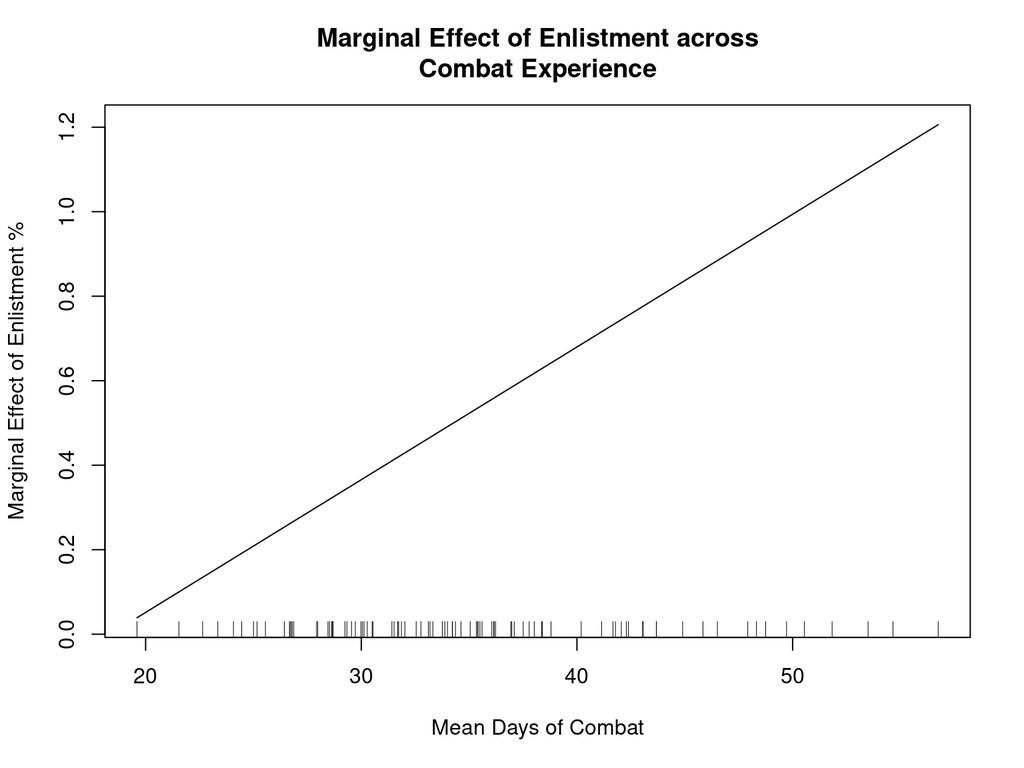

### Marginal Effects example:

Standard Errors:

```r
cov_mat = vcov(lm_iowa)

m_var = diag(cov_mat)['enlist_pct'] +
  combat_seq^2*diag(cov_mat)['enlist_pct:mean_combat_days'] +
  combat_seq*2*cov_mat['enlist_pct','enlist_pct:mean_combat_days']
mse = sqrt(m_var)

l = mfx - 1.96*mse
u = mfx + 1.96*mse
```

### Marginal Effects example:

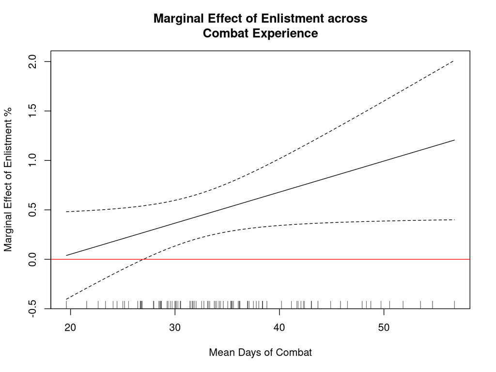

### Continuous Interactions

Hainmueller et al show this can go wrong:

`interflex` [package](https://yiqingxu.org/packages/interflex/articles/continuous.html) helpful for:

- checking linearity assumptions
- plotting linear and non-linear marginal effects
- no need to calculate marginal effects w/ SEs

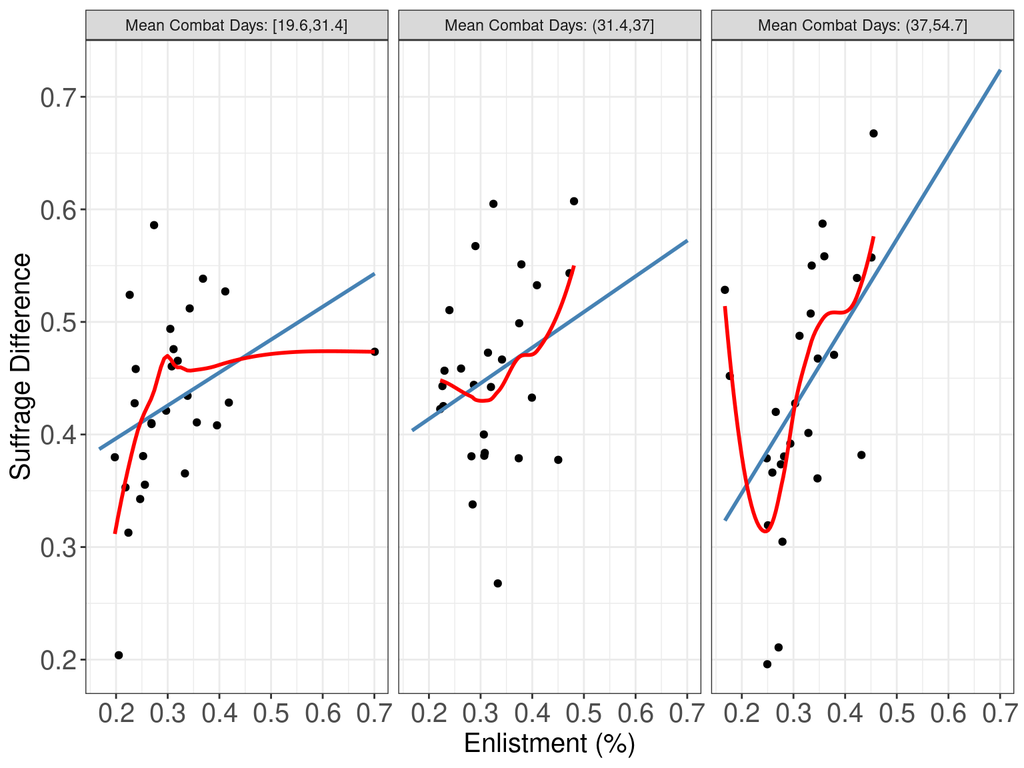

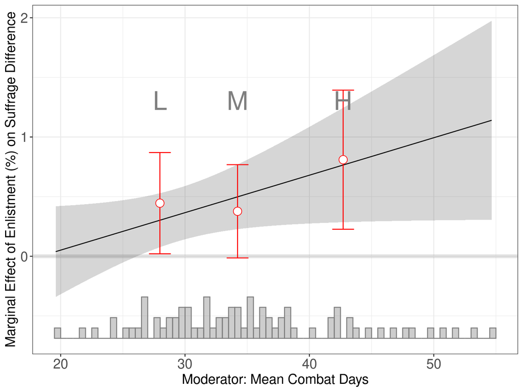

### Interactions:

- For **binary**-**binary** interactions, interpretation and estimation is straightforward.
- For any **continuous** interactions, estimation is tricky and we must calculate marginal effects.
  - Use `interflex` package to handle this
  - Check for common support
  - Get tests of linearity, non-linear interactions, SEs, plots